# Research Question 1: Is there measurement invariance?

Kirsten van Kessel

2024-01-16

#### Setup

```r
# load libraries
library(haven)
library(lavaan)
library(dplyr)
library(ggplot2)
library(countrycode)

# load data
data <- read_sav("../data/CY07_MSU_STU_QQQ.sav") # original data

# select subset variables
data <- data %>% select(CNT, CNTSTUID, LANGTEST_QQQ, ST011Q01TA:ST011Q16NA, ST011D17TA:ST011D19TA, ST012Q01TA:ST012Q09NA, ST013Q01TA, HOMEPOS, HISEI, PAREDINT, ESCS)
head(data)
```

```
## # A tibble: 6 × 32
##   CNT          CNTSTUID LANGTEST_QQQ ST011Q01TA ST011Q02TA ST011Q03TA ST011Q04TA
##   <chr+lbl>       <dbl> <dbl+lbl>    <dbl+lbl>  <dbl+lbl>  <dbl+lbl>  <dbl+lbl>
## 1 ALB [Albani…   800251 140 [Albani… 1 [Yes]    1 [Yes]    1 [Yes]    1 [Yes]
## 2 ALB [Albani…   800402 140 [Albani… 1 [Yes]    1 [Yes]    1 [Yes]    1 [Yes]
## 3 ALB [Albani…   801902 140 [Albani… 1 [Yes]    1 [Yes]    1 [Yes]    2 [No]
## 4 ALB [Albani…   803546 140 [Albani… 1 [Yes]    2 [No]     2 [No]     2 [No]
## 5 ALB [Albani…   804776 140 [Albani… 1 [Yes]    1 [Yes]    1 [Yes]    1 [Yes]
## 6 ALB [Albani…   804825 140 [Albani… 1 [Yes]    1 [Yes]    1 [Yes]    1 [Yes]
## # ℹ 25 more variables: ST011Q05TA <dbl+lbl>, ST011Q06TA <dbl+lbl>,
## #   ST011Q07TA <dbl+lbl>, ST011Q08TA <dbl+lbl>, ST011Q09TA <dbl+lbl>,
## #   ST011Q10TA <dbl+lbl>, ST011Q11TA <dbl+lbl>, ST011Q12TA <dbl+lbl>,
## #   ST011Q16NA <dbl+lbl>, ST011D17TA <chr+lbl>, ST011D18TA <chr+lbl>,
## #   ST011D19TA <chr+lbl>, ST012Q01TA <dbl+lbl>, ST012Q02TA <dbl+lbl>,
## #   ST012Q03TA <dbl+lbl>, ST012Q05NA <dbl+lbl>, ST012Q06NA <dbl+lbl>,
## #   ST012Q07NA <dbl+lbl>, ST012Q08NA <dbl+lbl>, ST012Q09NA <dbl+lbl>, …
```

```r
# set seed
set.seed(679)
```

#### The configural and metric variance models: Method and evaluation

We start with building the model, which is a model in which HISEI, PAREDINT and HOMEPOS are the three observed variables that are loading onto the latent variable ESCS. For the configural invariance model, we let the factor loadings and intercepts be freely estimated. Only the factor loading of HISEI is fixed to one for scaling. We notice that this results in a model with zero degrees of freedom. To fix this, we fix the factor loading of PAREDINT to be 1 in one country, resulting in 1 degree of freedom. This results in a model with Chi-Square = 10.160, df = 1, p-value = 0.001, AIC = 3999507, BIC = 4007582, TLI = 0.991, CFI = 1.000, RMSEA = 0.036. This indicates a good fitting model.

For the metric invariance model, we fix all factor loadings to be the same in every country. This results in a model with Chi-Square = 11878.74, df = 158, p-value = 0.000, AIC = 4011061, BIC = 4017373, TLI = 0.930, CFI = 0.954, RMSEA = 0.103. This indicates a bad fitting model. We see that the AIC, BIC and RMSEA are higher in the metric invariance model as in the configural invariance model. TLI and CFI are lower. This both indicates that the configural invariance model fits better.

Metric invariance is not achieved. We look at modification indices to inspect how we could change this model to improve the fit. We see that for every country, the model would improve if we free the loadings of HISEI (let the loadings differ from other countries) and if we would let the indicator have a covariance. HISEI is the indicator with a loading of 1 to identify the scale. We do not have the degrees of freedom to add the covariances.

#### The configural and metric variance models

```r
# scale variables
data$HISEI <- scale(data$HISEI)
data$HOMEPOS <- scale(data$HOMEPOS)
data$PAREDINT <- scale(data$PAREDINT)

# make model
model <- '
ESCS_c =~ HISEI + PAREDINT + HOMEPOS
'

# Configural invariance
fit_conf <- lavaan::cfa(model = model, data = data, group = "CNT")
summary(fit_conf) # zero degrees of freedom
```

```
## lavaan 0.6-18 ended normally after 500 iterations
##
##   Estimator                                         ML
##   Optimization method                           NLMINB
##   Number of model parameters                       720
##
##   Number of observations per group:               Used       Total
##     ALB                                           6118        6359
##     ARE                                          17156       19277
##     ARG                                          10526       11975
##     AUS                                          12045       14273
##     AUT                                           6219        6802
##     BEL                                           7749        8475
##     BGR                                           4217        5294
##     BIH                                           5981        6480
##     BLR                                           5593        5803
##     BRA                                           9279       10691
##     BRN                                           6504        6828
##     CAN                                          19772       22653
##     CHE                                           5370        5822
##     CHL                                           6784        7621
##     COL                                           7052        7522
##     CRI                                           7005        7221
##     CZE                                           6427        7019
##     DEU                                           4213        5451
##     DNK                                           6969        7657
##     DOM                                           5218        5674
##     ESP                                          33746       35943
##     EST                                           4884        5316
##     FIN                                           5277        5649
##     FRA                                           5735        6308
##     GBR                                          11329       13818
##     GEO                                           4544        5572
##     GRC                                           6065        6403
##     HKG                                           5411        6037
##     HRV                                           6351        6609
##     HUN                                           4810        5132
##     IDN                                          11769       12098
##     IRL                                           5203        5577
##     ISL                                           3073        3296
```

[output cut: 1964 more lines]

```
##     PAREDINT          1.164    0.033   34.790    0.000
##     HOMEPOS           0.876    0.025   34.815    0.000
##
## Intercepts:
##                    Estimate  Std.Err  z-value  P(>|z|)
##    .HISEI            -0.624    0.013  -48.516    0.000
##    .PAREDINT         -1.161    0.015  -78.738    0.000
##    .HOMEPOS          -1.044    0.011  -92.350    0.000
##
## Variances:
##                    Estimate  Std.Err  z-value  P(>|z|)
##    .HISEI             0.459    0.014   32.959    0.000
##    .PAREDINT          0.586    0.018   31.808    0.000
##    .HOMEPOS           0.357    0.011   33.208    0.000
##     ESCS_c            0.424    0.018   23.406    0.000
```

```r
# The loading of HISEI is fixed to be one in all countries for scaling
# To get 1 degree of freedom instead of 1, we fix the loading of PAREDINT to be 1,
# but only in one country

model_conf <- '
ESCS_c =~ 1*HISEI + c(1,NA,NA,NA,NA,NA,NA,NA,NA,NA,NA,NA,NA,NA,NA,NA,NA,NA,NA,NA,NA,NA,NA,NA,NA,NA,NA,NA,NA,NA,NA,NA,NA,NA,NA,NA,NA,NA,NA,NA,NA,NA,NA,NA,NA,NA,NA,NA,NA,NA,NA,NA,NA,NA,NA,NA,NA,NA,NA,NA,NA,NA,NA,NA,NA,NA,NA,NA,NA,NA,NA,NA,NA,NA,NA,NA,NA,NA,NA,NA)*PAREDINT + HOMEPOS
'

fit_conf2 <- lavaan::cfa(model = model_conf, data = data, group = "CNT")
summary(fit_conf2)
```

```
## lavaan 0.6-18 ended normally after 480 iterations
##
##   Estimator                                         ML
##   Optimization method                           NLMINB
##   Number of model parameters                       719
##
##   Number of observations per group:               Used       Total
##     ALB                                           6118        6359
##     ARE                                          17156       19277
##     ARG                                          10526       11975
##     AUS                                          12045       14273
##     AUT                                           6219        6802
##     BEL                                           7749        8475
##     BGR                                           4217        5294
##     BIH                                           5981        6480
##     BLR                                           5593        5803
##     BRA                                           9279       10691
##     BRN                                           6504        6828
##     CAN                                          19772       22653
##     CHE                                           5370        5822
##     CHL                                           6784        7621
##     COL                                           7052        7522
##     CRI                                           7005        7221
##     CZE                                           6427        7019
##     DEU                                           4213        5451
##     DNK                                           6969        7657
##     DOM                                           5218        5674
##     ESP                                          33746       35943
##     EST                                           4884        5316
##     FIN                                           5277        5649
##     FRA                                           5735        6308
##     GBR                                          11329       13818
##     GEO                                           4544        5572
##     GRC                                           6065        6403
##     HKG                                           5411        6037
##     HRV                                           6351        6609
##     HUN                                           4810        5132
##     IDN                                          11769       12098
##     IRL                                           5203        5577
##     ISL                                           3073        3296
```

[output cut: 1965 more lines]

```
##     PAREDINT          1.164    0.033   34.790    0.000
##     HOMEPOS           0.876    0.025   34.815    0.000
##
## Intercepts:
##                    Estimate  Std.Err  z-value  P(>|z|)
##    .HISEI            -0.624    0.013  -48.516    0.000
##    .PAREDINT         -1.161    0.015  -78.738    0.000
##    .HOMEPOS          -1.044    0.011  -92.350    0.000
##
## Variances:
##                    Estimate  Std.Err  z-value  P(>|z|)
##    .HISEI             0.459    0.014   32.959    0.000
##    .PAREDINT          0.586    0.018   31.808    0.000
##    .HOMEPOS           0.357    0.011   33.208    0.000
##     ESCS_c            0.424    0.018   23.406    0.000
```

```r
fitMeasures(fit_conf2) # fit measures: how well does the model fit?
```

```
##                  npar                  fmin                 chisq
##               719.000                 0.000                10.160
##                    df                pvalue        baseline.chisq
##                 1.000                 0.001            255197.972
##           baseline.df       baseline.pvalue                   cfi
##               240.000                 0.000                 1.000
##                   tli                  nnfi                   rfi
##                 0.991                 0.991                 0.990
##                   nfi                  pnfi                   ifi
##                 1.000                 0.004                 1.000
##                   rni                  logl     unrestricted.logl
##                 1.000          -1999034.292          -1999029.212
##                   aic                   bic                ntotal
##           3999506.583           4007582.146            557746.000
##                  bic2                 rmsea        rmsea.ci.lower
##           4005297.128                 0.036                 0.018
##        rmsea.ci.upper        rmsea.ci.level          rmsea.pvalue
##                 0.058                 0.900                 0.838
##        rmsea.close.h0 rmsea.notclose.pvalue     rmsea.notclose.h0
##                 0.050                 0.000                 0.080
##                   rmr            rmr_nomean                  srmr
##                 0.000                 0.000                 0.000
##          srmr_bentler   srmr_bentler_nomean                  crmr
##                 0.000                 0.000                 0.000
##           crmr_nomean            srmr_mplus     srmr_mplus_nomean
##                 0.000                 0.000                 0.000
##                 cn_05                 cn_01                   gfi
##            210878.460            364224.647                 1.000
##                  agfi                  pgfi                   mfi
##                 0.993                 0.001                 1.000
##                  ecvi
##                 0.003
```

```r
modificationIndices(fit_conf2, sort = TRUE, minimum.value = 0) # mod indices: what can we change to improve fit?
```

```
##          lhs op      rhs block group level     mi    epc sepc.lv sepc.all
## 2     ESCS_c =~ PAREDINT     1     1     1 10.152 -0.111  -0.063   -0.073
## 882    HISEI ~~  HOMEPOS     1     1     1 10.152  0.034   0.034    0.071
## 883 PAREDINT ~~  HOMEPOS     1     1     1 10.152 -0.034  -0.034   -0.077
## 1     ESCS_c =~    HISEI     1     1     1 10.152  0.111   0.063    0.069
##     sepc.nox
## 2     -0.073
## 882    0.071
## 883   -0.077
## 1      0.069
```

```r
# Metric invariance
fit_metric <- lavaan::cfa(model = model, data = data, group = "CNT",
                          group.equal = c("loadings"))
summary(fit_metric)
```

```
## lavaan 0.6-18 ended normally after 186 iterations
##
##   Estimator                                         ML
##   Optimization method                           NLMINB
##   Number of model parameters                       720
##   Number of equality constraints                   158
##
##   Number of observations per group:               Used       Total
##     ALB                                           6118        6359
##     ARE                                          17156       19277
##     ARG                                          10526       11975
##     AUS                                          12045       14273
##     AUT                                           6219        6802
##     BEL                                           7749        8475
##     BGR                                           4217        5294
##     BIH                                           5981        6480
##     BLR                                           5593        5803
##     BRA                                           9279       10691
##     BRN                                           6504        6828
##     CAN                                          19772       22653
##     CHE                                           5370        5822
##     CHL                                           6784        7621
##     COL                                           7052        7522
##     CRI                                           7005        7221
##     CZE                                           6427        7019
##     DEU                                           4213        5451
##     DNK                                           6969        7657
##     DOM                                           5218        5674
##     ESP                                          33746       35943
##     EST                                           4884        5316
##     FIN                                           5277        5649
##     FRA                                           5735        6308
##     GBR                                          11329       13818
##     GEO                                           4544        5572
##     GRC                                           6065        6403
##     HKG                                           5411        6037
##     HRV                                           6351        6609
##     HUN                                           4810        5132
##     IDN                                          11769       12098
##     IRL                                           5203        5577
```

[output cut: 1966 more lines]

```
##     PAREDIN (.p2.)    0.889    0.004  250.765    0.000
##     HOMEPOS (.p3.)    0.646    0.003  255.796    0.000
##
## Intercepts:
##                    Estimate  Std.Err  z-value  P(>|z|)
##    .HISEI            -0.624    0.013  -47.101    0.000
##    .PAREDINT         -1.161    0.014  -80.195    0.000
##    .HOMEPOS          -1.044    0.011  -94.837    0.000
##
## Variances:
##                    Estimate  Std.Err  z-value  P(>|z|)
##    .HISEI             0.358    0.013   28.664    0.000
##    .PAREDINT          0.662    0.016   41.868    0.000
##    .HOMEPOS           0.405    0.009   43.288    0.000
##     ESCS_c            0.578    0.016   36.854    0.000
```

```r
fitMeasures(fit_metric) # fit measures: how well does the model fit?
```

```
##                  npar                  fmin                 chisq
##               562.000                 0.011             11878.741
##                    df                pvalue        baseline.chisq
##               158.000                 0.000            255197.972
##           baseline.df       baseline.pvalue                   cfi
##               240.000                 0.000                 0.954
##                   tli                  nnfi                   rfi
##                 0.930                 0.930                 0.929
##                   nfi                  pnfi                   ifi
##                 0.953                 0.628                 0.954
##                   rni                  logl     unrestricted.logl
##                 0.954          -2004968.582          -1999029.212
##                   aic                   bic                ntotal
##           4011061.164           4017373.356            557746.000
##                  bic2                 rmsea        rmsea.ci.lower
##           4015587.292                 0.103                 0.102
##        rmsea.ci.upper        rmsea.ci.level          rmsea.pvalue
##                 0.105                 0.900                 0.000
##        rmsea.close.h0 rmsea.notclose.pvalue     rmsea.notclose.h0
##                 0.050                 1.000                 0.080
##                   rmr            rmr_nomean                  srmr
##                 0.038                 0.047                 0.043
##          srmr_bentler   srmr_bentler_nomean                  crmr
##                 0.043                 0.052                 0.038
##           crmr_nomean            srmr_mplus     srmr_mplus_nomean
##                 0.054                 0.040                 0.048
##                 cn_05                 cn_01                   gfi
##              8843.793              9498.196                 0.991
##                  agfi                  pgfi                   mfi
##                 0.957                 0.217                 0.990
##                  ecvi
##                 0.023
```

```r
modificationIndices(fit_metric, sort = TRUE, minimum.value = 0) # mod indices: what can we change to improve fit?
```

```
##           lhs op      rhs block group level      mi    epc sepc.lv sepc.all
## 1131 PAREDINT ~~  HOMEPOS    31    31     1 894.623  0.227   0.227    0.321
## 331    ESCS_c =~    HISEI    31    31     1 894.572 -0.777  -0.554   -0.674
## 1176 PAREDINT ~~  HOMEPOS    46    46     1 655.216  0.513   0.513    0.345
## 496    ESCS_c =~    HISEI    46    46     1 655.103 -1.361  -1.103   -1.285
## 815    ESCS_c =~    HISEI    75    75     1 590.942 -0.618  -0.535   -0.542
## 1263 PAREDINT ~~  HOMEPOS    75    75     1 590.905  0.266   0.266    0.351
## 1207    HISEI ~~ PAREDINT    57    57     1 408.924 -0.325  -0.325   -0.794
## 1206 PAREDINT ~~  HOMEPOS    56    56     1 357.944  0.294   0.294    0.311
## 606    ESCS_c =~    HISEI    56    56     1 357.927 -0.662  -0.582   -0.523
## 1129    HISEI ~~ PAREDINT    31    31     1 352.936 -0.185  -0.185   -0.474
## 1073    HISEI ~~  HOMEPOS    12    12     1 333.512  0.089   0.089    0.147
## 1182 PAREDINT ~~  HOMEPOS    48    48     1 332.878  0.202   0.202    0.277
## 518    ESCS_c =~    HISEI    48    48     1 332.846 -0.498  -0.419   -0.445
## 1241    HISEI ~~  HOMEPOS    68    68     1 307.771 -0.234  -0.234   -0.423
```

[output cut: 627 more lines]

```r
# Chi-square difference test
lavaan::anova(fit_conf2, fit_metric) # Metric is significantly worse, we stop
```

```
##
## Chi-Squared Difference Test
##
##             Df     AIC     BIC    Chisq Chisq diff   RMSEA Df diff Pr(>Chisq)
## fit_conf2    1 3999507 4007582    10.16
## fit_metric 158 4011061 4017373 11878.74      11869 0.10344     157  < 2.2e-16
##
## fit_conf2
## fit_metric ***
## ---
## Signif. codes:  0 '***' 0.001 '**' 0.01 '*' 0.05 '.' 0.1 ' ' 1
```

#### Making graph of the intercepts (means) per country

```r
# extract intercepts
country_list <- unique(data$CNT)
nu <- matrix(0, nrow = 80, ncol = 3)

for(i in 1:length(country_list)){
  nu_CNT <- inspect(fit_conf2, what='std')[i][[1]]$nu
  nu_CNT <- nu_CNT %>% as.matrix() %>% t()
  nu[i,] <- nu_CNT
}
head(nu)
```

```
##             [,1]        [,2]       [,3]
## [1,] -0.23384641 -0.42395801 -0.6796885
## [2,]  0.48939370  0.54624731  0.2589549
## [3,] -0.19462155 -0.24666415 -0.5529587
## [4,]  0.27299124  0.27603976  1.1084638
## [5,]  0.04378427  0.09805578  0.8174692
## [6,]  0.12622505  0.30300744  0.6835963
```

```r
# make dataframe
nu <- as.data.frame(nu)
colnames(nu) <- c("HISEI", "PAREDINT", "HOMEPOS") # change columnnames
nu$COUNTRY <- country_list # make variable for country
head(nu)
```

```
##         HISEI    PAREDINT    HOMEPOS COUNTRY
## 1 -0.23384641 -0.42395801 -0.6796885     ALB
## 2  0.48939370  0.54624731  0.2589549     ARE
## 3 -0.19462155 -0.24666415 -0.5529587     ARG
## 4  0.27299124  0.27603976  1.1084638     AUS
## 5  0.04378427  0.09805578  0.8174692     AUT
## 6  0.12622505  0.30300744  0.6835963     BEL
```

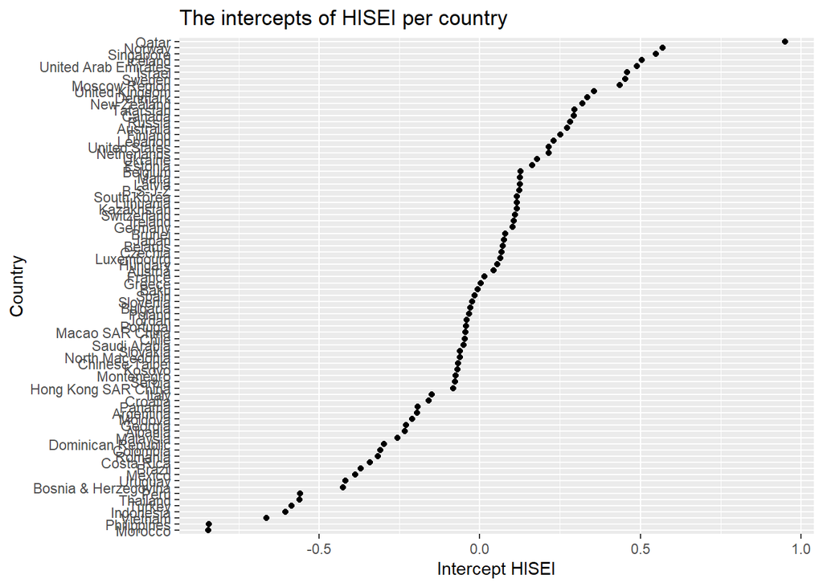

```r
# Change country codes into country names
# KSV, QAZ, QCI, QMR, QRT, and TAP do not work with the function, so are coded seperately
nu$COUNTRY[nu$COUNTRY == "KSV"] <- "Kosovo"
nu$COUNTRY[nu$COUNTRY == "QAZ"] <- "Baku"
nu$COUNTRY[nu$COUNTRY == "QCI"] <- "B-S-J-Z"
nu$COUNTRY[nu$COUNTRY == "QMR"] <- "Moscow Region"
nu$COUNTRY[nu$COUNTRY == "QRT"] <- "Tatarstan"
nu$COUNTRY[nu$COUNTRY == "TAP"] <- "Chinese Taipei"
nu$COUNTRY[nu$COUNTRY != "Kosovo" & nu$COUNTRY != "Baku"
          & nu$COUNTRY != "B-S-J-Z" & nu$COUNTRY != "Moscow Region"
          & nu$COUNTRY != "Tatarstan" & nu$COUNTRY != "Chinese Taipei"] <-
  countrycode(nu$COUNTRY[nu$COUNTRY != "Kosovo" & nu$COUNTRY != "Baku"
              & nu$COUNTRY != "B-S-J-Z" & nu$COUNTRY != "Moscow Region"
              & nu$COUNTRY != "Tatarstan" & nu$COUNTRY != "Chinese Taipei"],
  "iso3c", "country.name")

# make a plot for the intercepts of HISEI
nu_HISEI_plot <- ggplot(nu, aes(x=HISEI, y=reorder(COUNTRY, HISEI))) + geom_point() +
  ggtitle("The intercepts of HISEI per country") +
  ylab("Country") +
  xlab("Intercept HISEI")
nu_HISEI_plot
```

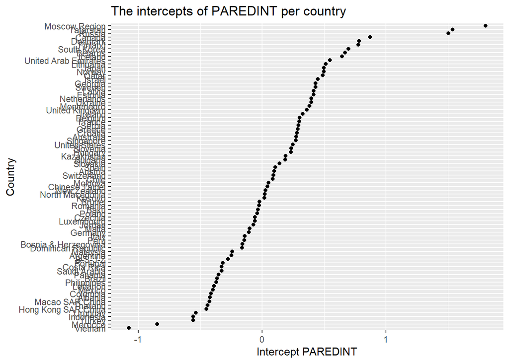

```r
# make a plot for the intercepts of PAREDINT
nu_PAREDINT_plot <- ggplot(nu, aes(x=PAREDINT, y=reorder(COUNTRY, PAREDINT))) + geom_point() +
  ggtitle("The intercepts of PAREDINT per country") +
  ylab("Country") +
  xlab("Intercept PAREDINT")
nu_PAREDINT_plot
```

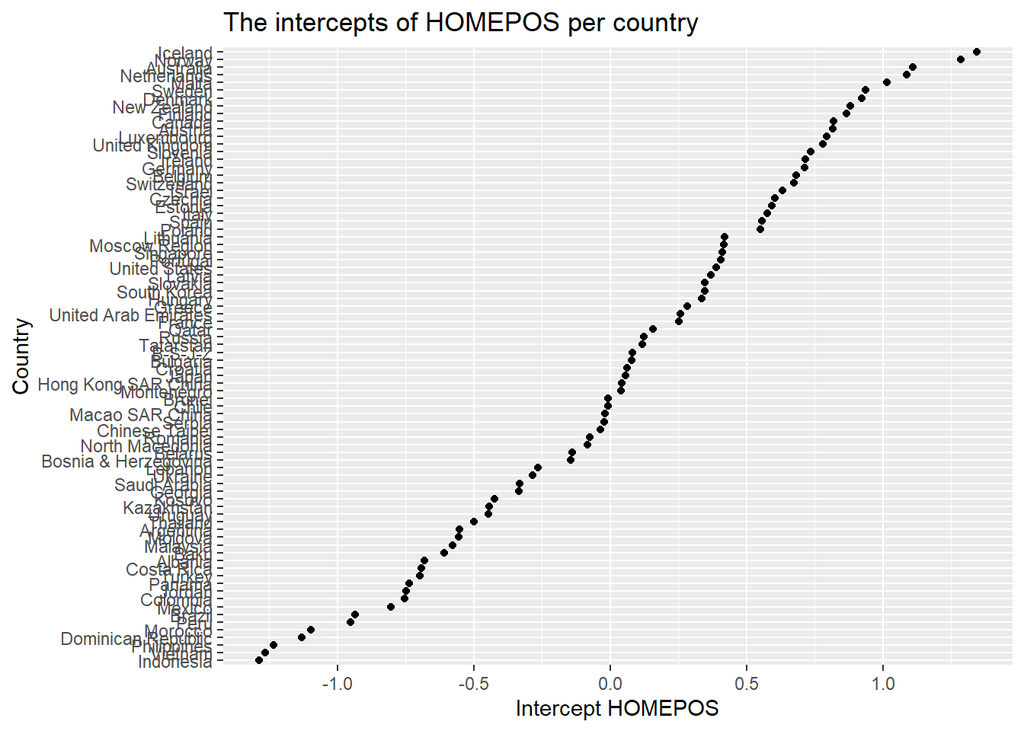

```r
# make a plot for the intercepts of HOMEPOS
nu_HOMEPOS_plot <- ggplot(nu, aes(x=HOMEPOS, y=reorder(COUNTRY, HOMEPOS))) + geom_point() +
  ggtitle("The intercepts of HOMEPOS per country") +
  ylab("Country") +
  xlab("Intercept HOMEPOS")
nu_HOMEPOS_plot
```

```r
# when saving: height = 1000
```

```r
# extract intercepts
country_list <- unique(data$CNT)
lambda <- matrix(0, nrow = 80, ncol = 3)

for(i in 1:length(country_list)){
  lambda_CNT <- inspect(fit_conf2, what='std')[i][[1]]$lambda
  lambda_CNT <- lambda_CNT %>% as.matrix() %>% t()
  lambda[i,] <- lambda_CNT
}
head(lambda)
```

```
##           [,1]      [,2]      [,3]
## [1,] 0.6226216 0.6509011 0.6268290
## [2,] 0.4412823 0.7551524 0.3102201
## [3,] 0.7508526 0.7106585 0.6078211
## [4,] 0.7074065 0.6586650 0.4263218
## [5,] 0.7171156 0.6360278 0.5269805
## [6,] 0.7973628 0.5941170 0.5584622
```

```r
# make dataframe
lambda <- as.data.frame(nu)
colnames(lambda) <- c("HISEI", "PAREDINT", "HOMEPOS") # change columnnames
lambda$COUNTRY <- nu$COUNTRY # make variable for country
head(lambda)
```

```
##         HISEI    PAREDINT    HOMEPOS                   NA              COUNTRY
## 1 -0.23384641 -0.42395801 -0.6796885              Albania              Albania
## 2  0.48939370  0.54624731  0.2589549 United Arab Emirates United Arab Emirates
## 3 -0.19462155 -0.24666415 -0.5529587            Argentina            Argentina
## 4  0.27299124  0.27603976  1.1084638            Australia            Australia
## 5  0.04378427  0.09805578  0.8174692              Austria              Austria
## 6  0.12622505  0.30300744  0.6835963              Belgium              Belgium
```

[figure not shown]

```r
# make a plot for the loadings of HISEI
lambda_HISEI_plot <- ggplot(lambda, aes(x=HISEI, y=reorder(COUNTRY, HISEI))) + geom_point() +
  ggtitle("The factor loadings of HISEI per country") +
  ylab("Country") +
  xlab("Factor loading HISEI")
lambda_HISEI_plot
```

[figure not shown]

```r
# make a plot for the loadings of PAREDINT
lambda_PAREDINT_plot <- ggplot(lambda, aes(x=PAREDINT, y=reorder(COUNTRY, PAREDINT))) + geom_point() +
  ggtitle("The factor loadings of PAREDINT per country") +
  ylab("Country") +
  xlab("Factor loading PAREDINT")
lambda_PAREDINT_plot
```

[figure not shown]

```r
# make a plot for the loadings of HOMEPOS
lambda_HOMEPOS_plot <- ggplot(lambda, aes(x=HOMEPOS, y=reorder(COUNTRY, HOMEPOS))) + geom_point() +
  ggtitle("The factor loadings of HOMEPOS per country") +
  ylab("Country") +
  xlab("Factor loading HOMEPOS")
lambda_HOMEPOS_plot
```

```r
# when saving: height = 1000
```

#### Improving the metric invariance model

We try to follow the modification indices to achieve partial invariance. This is reached when the model does not significantly differ from the configural invariance model.

1. PAREDINT ~~ HOMEPOS free in group 31
2. PAREDINT ~~ HOMEPOS free in group 46
3. PAREDINT ~~ HOMEPOS free in group 75
4. HISEI ~~ PAREDINT free in group 57
5. ESCS_c =~ HISEI free in group 56
6. ESCS_c =~ HISEI free in group 48
7. ESCS_c =~ HISEI free in group 57
8. HISEI ~~ HOMEPOS free in group 68
9. ESCS_c =~ HISEI free in group 10
10. PAREDINT ~~ HOMEPOS free in group 15
11. HISEI ~~ HOMEPOS free in group 63
12. HISEI ~~ HOMEPOS free in group 68
13. HISEI ~~ HOMEPOS free in group 60
14. HISEI ~~ HOMEPOS free in group 57
15. ESCS_c =~ HISEI free in group 16
16. HISEI ~~ HOMEPOS free in group 12
17. HISEI ~~ PAREDINT free in group 58
18. ESCS_c =~ HISEI free in group 80
19. HISEI ~~ HOMEPOS free in group 21
20. HISEI ~~ HOMEPOS free in group 3
21. PAREDINT ~~ HOMEPOS free in group 61
22. HISEI ~~ HOMEPOS free in group 65
23. PAREDINT ~~ HOMEPOS free in group 41
24. ESCS_c =~ HISEI free in group 76
25. PAREDINT ~~ HOMEPOS free in group 58
26. PAREDINT ~~ HOMEPOS free in group 36
27. ESCS_c =~ HISEI free in group 60
28. HISEI ~~ PAREDINT free in group 60
29. ESCS_c =~ HISEI free in group 78
30. PAREDINT ~~ HOMEPOS free in group 45
31. HISEI ~~ PAREDINT free in group 52
32. HISEI ~~ PAREDINT free in group 11
33. HISEI ~~ HOMEPOS free in group 67
34. ESCS_c =~ HISEI free in group 69
35. HISEI ~~ PAREDINT free in group 1
36. ESCS_c =~ HISEI free in group 2
37. HISEI ~~ PAREDINT free in group 3
38. ESCS_c =~ HISEI free in group 3
39. HISEI ~~ PAREDINT free in group 25
40. HISEI ~~ PAREDINT free in group 59
41. HISEI ~~ HOMEPOS free in group 19
42. HISEI ~~ PAREDINT free in group 50
43. HISEI ~~ PAREDINT free in group 72
44. PAREDINT ~~ HOMEPOS free in group 23
45. HISEI ~~ PAREDINT free in group 35
46. ESCS_c =~ HISEI free in group 29
47. PAREDINT ~~ HOMEPOS free in group 9
48. PAREDINT ~~ HOMEPOS free in group 42
49. PAREDINT ~~ HOMEPOS free in group 63
50. PAREDINT ~~ HOMEPOS free in group 20
51. ESCS_c =~ HISEI free in group 28
52. HISEI ~~ HOMEPOS free in group 18
53. HISEI ~~ HOMEPOS free in group 43
54. HISEI ~~ PAREDINT free in group 45
55. HISEI ~~ PAREDINT free in group 70
56. HISEI ~~ PAREDINT free in group 16
57. HISEI ~~ HOMEPOS free in group 4
58. HISEI ~~ PAREDINT free in group 2
59. PAREDINT ~~ HOMEPOS free in group 14
60. PAREDINT ~~ HOMEPOS free in group 74
61. ESCS_c =~ HISEI free in group 79
62. HISEI ~~ HOMEPOS free in group 61
63. HISEI ~~ PAREDINT free in group 13
64. HISEI ~~ PAREDINT free in group 26
65. HISEI ~~ PAREDINT free in group 66
66. PAREDINT ~~ HOMEPOS free in group 1
67. ESCS_c =~ HISEI free in group 7
68. HISEI ~~ PAREDINT free in group 8
69. HISEI ~~ HOMEPOS free in group 10
70. HISEI ~~ PAREDINT free in group 76
71. HISEI ~~ PAREDINT free in group 44
72. HISEI ~~ PAREDINT free in group 39
73. HISEI ~~ HOMEPOS free in group 64
74. ESCS_c =~ HISEI free in group 40
75. PAREDINT ~~ HOMEPOS free in group 50
76. HISEI ~~ HOMEPOS free in group 55
77. HISEI ~~ HOMEPOS free in group 17
78. PAREDINT ~~ HOMEPOS free in group 43
79. HISEI ~~ PAREDINT free in group 24
80. PAREDINT ~~ HOMEPOS free in group 62
81. ESCS_c =~ HISEI free in group 63
82. HISEI ~~ PAREDINT free in group 78
83. HISEI ~~ PAREDINT free in group 18
84. ESCS_c =~ HISEI free in group 18
85. HISEI ~~ HOMEPOS free in group 34
86. HISEI ~~ HOMEPOS free in group 38
87. HISEI ~~ PAREDINT free in group 31
88. ESCS_c =~ HISEI free in group 31
89. HISEI ~~ HOMEPOS free in group 15
90. HISEI ~~ PAREDINT free in group 47
91. HISEI ~~ HOMEPOS free in group 36
92. HISEI ~~ HOMEPOS free in group 14
93. HISEI ~~ HOMEPOS free in group 79
94. PAREDINT ~~ HOMEPOS free in group 37
95. HISEI ~~ PAREDINT free in group 51
96. PAREDINT ~~ HOMEPOS free in group 12
97. HISEI ~~ PAREDINT free in group 30
98. ESCS_c =~ HISEI free in group 58
99. HISEI ~~ HOMEPOS free in group 33
100. ESCS_c =~ HISEI free in group 67
101. ESCS_c =~ HISEI free in group 70
102. HISEI ~~ HOMEPOS free in group 6
103. HISEI ~~ HOMEPOS free in group 72
104. HISEI ~~ PAREDINT free in group 74
105. HISEI ~~ HOMEPOS free in group 20
106. HISEI ~~ HOMEPOS free in group 39
107. HISEI ~~ PAREDINT free in group 5
108. PAREDINT ~~ HOMEPOS free in group 13
109. HISEI ~~ PAREDINT free in group 37
110. ESCS_c =~ HISEI free in group 25
111. HISEI ~~ HOMEPOS free in group 69
112. HISEI ~~ HOMEPOS free in group 75 -> Model fits not significantly worse than the configural invariance model. We have achieved partial metric invariance.

```r
model <- '
ESCS_c =~ c(1,NA,NA,1,1,1,NA,1,1,NA,1,1,1,1,1,NA,1,NA,1,1,1,1,1,1,NA,1,1,NA,NA,1,NA,1,1,1,1,1,1,1,1,NA,1,1,1,1,1,1,1,NA,1,1,1,1,1,1,1,NA,NA,NA,1,NA,1,1,NA,1,1,1,NA,1,NA,NA,1,1,1,1,1,NA,1,NA,NA,NA) *HISEI + PAREDINT + HOMEPOS

PAREDINT    ~~ c(NA,0,0,0,0,0,0,0,NA,0,0,NA,NA,NA,NA,0,0,0,0,NA,0,0,NA,0,0,0,0,0,0,0,NA,0,0,0,0,NA,NA,0,0,0,NA,NA,NA,0,NA,NA,0,0,0,NA,0,0,0,0,0,0,0,NA,0,0,NA,NA,NA,0,NA,0,0,NA,0,0,0,0,0,NA,NA,0,0,0,0,0) *HOMEPOS

HISEI   ~~ c(NA,NA,NA,0,NA,0,0,NA,0,0,NA,0,NA,0,0,NA,0,NA,0,0,0,0,0,NA,NA,NA,0,0,0,NA,NA,0,0,0,NA,0,NA,0,NA,0,0,0,0,NA,NA,0,NA,0,0,NA,NA,NA,0,0,0,0,NA,NA,NA,NA,0,0,0,0,0,NA,0,0,0,NA,0,NA,0,NA,0,NA,0,NA,0,0) *PAREDINT

HISEI   ~~ c(0,0,NA,NA,0,NA,0,0,0,NA,0,NA,0,NA,NA,0,NA,NA,NA,NA,NA,0,0,0,0,0,0,0,0,0,0,0,NA,NA,0,NA,0,NA,NA,0,0,0,NA,0,0,0,0,0,0,0,0,0,0,0,NA,0,NA,0,0,NA,NA,0,NA,NA,NA,0,NA,NA,NA,0,0,NA,0,0,NA,0,0,0,NA,0) *HOMEPOS

'

fit_partial <- lavaan::cfa(model = model, data = data, group = "CNT",
                          group.equal = c("loadings"),
                          group.partial = c("ESCS_c =~ HISEI"))
lavaan::anova(fit_conf2, fit_partial) # model fits NOT significantly worse
```

```
##
## Chi-Squared Difference Test
##
##             Df     AIC     BIC  Chisq Chisq diff     RMSEA Df diff Pr(>Chisq)
## fit_conf2    1 3999507 4007582 10.160
## fit_partial 45 3999478 4007059 69.581     59.421 0.0070901      44    0.06024 .
## ---
## Signif. codes:  0 '***' 0.001 '**' 0.01 '*' 0.05 '.' 0.1 ' ' 1
```

```r
modificationIndices(fit_partial, sort = TRUE, minimum.value = 4)
```

```
##           lhs op      rhs block group level       mi    epc sepc.lv sepc.all
## 1037   ESCS_c =~    HISEI    75    75     1 1087.536 -0.623  -0.610   -0.639
## 1041    HISEI ~~ PAREDINT    75    75     1  201.276  0.264   0.264    0.247
## 943     HISEI ~~ PAREDINT    68    68     1  185.687  2.804   2.804    7.728
## 939    ESCS_c =~    HISEI    68    68     1   29.851 -0.463  -0.467   -0.438
## 1069    HISEI ~~ PAREDINT    77    77     1    5.513 -0.023  -0.023   -0.056
## 606  PAREDINT ~~  HOMEPOS    44    44     1    5.306 -0.014  -0.014   -0.055
## 603    ESCS_c =~    HISEI    44    44     1    5.306  0.098   0.061    0.063
## 608     HISEI ~~  HOMEPOS    44    44     1    5.306  0.020   0.020    0.052
## 743    ESCS_c =~    HISEI    54    54     1    5.062 -0.102  -0.061   -0.071
## 746  PAREDINT ~~  HOMEPOS    54    54     1    5.062  0.013   0.013    0.040
## 757    ESCS_c =~    HISEI    55    55     1    4.016 -0.103  -0.077   -0.084
## 761     HISEI ~~ PAREDINT    55    55     1    4.016 -0.040  -0.040   -0.094
## 760  PAREDINT ~~  HOMEPOS    55    55     1    4.016  0.021   0.021    0.036
##      sepc.nox
## 1037   -0.639
## 1041    0.247
## 943     7.728
## 939    -0.438
## 1069   -0.056
## 606    -0.055
## 603     0.063
## 608     0.052
## 743    -0.071
## 746     0.040
## 757    -0.084
## 761    -0.094
## 760     0.036
```